# RA Ex Vivo 16S Analysis

Renuka Nayak

8/20/20

# 1 Introduction

This R markdown document provides code used in the analysis of 16S-seq data from RA patient fecal samples treated ex vivo with either MTX or vehicle control (DMSO). These are from our manuscript:

Nayak et al, Methotrexate impacts conserved pathways in diverse human gut bacteria leading to decreased host immune activation. In revision.

# 2 Experimental Design

## 2.1 Analysis Notes

Some of the code in this document has been adapted from: https://f1000researchdata.s3.amazonaws.com/manuscripts/10545/387d9a79-c4ab-4676-8466-583e3fb2c85f_8986_-_susan_holmes_v2.pdf?doi=10.12688/f1000research.8986.2

## 2.2 Manuscript Results

The code in this Rmd was used to support the following paragraph from the Results of our manuscript:

“16S-seq of endpoint samples revealed a significant decrease in richness (Figure S4C) and shift in community structure (Figures 5B-E) in response to MTX. Consistent with our studies in mice and on isolates, Bacteroidetes decreased (Figure 5F) and Actinobacteria increased (Figure 5G). We also detected significant shifts in the abundance of 17 genera and 20 ASVs (Table S2C, Figure 5H). This included multiple MTX-modulated ASVs seen in our in vivo experiments: B. thetaiotaomicron (ASV23), B. uniformis (ASV14), B. vulgatus (ASV26), C. aerofaciens (ASV44), and B. ovatus (ASV496), which changed in a direction similar to what was seen in vivo.”"

# 3 Set Up

## 3.1 Load Libraries

```r
knitr::opts_chunk$set(echo = TRUE, message = FALSE, warning = FALSE)
library(phyloseq); packageVersion("phyloseq")
```

```
## [1] '1.30.0'
```

```r
library(ggplot2); packageVersion("ggplot2")
```

```
## [1] '3.3.0'
```

```r
library(biomformat)
library(ape)
library(readxl)
library(ggthemes)
library(tidyverse)
library(RColorBrewer)
library(gridExtra)
library(qiime2R)
library(nlme)
# Load packages into session, and print package version
#sapply(c(.cran_packages, .bioc_packages), require, character.only = TRUE)
set.seed(100)

theme_set(theme_classic(base_size = 9) +theme(axis.text = element_text(colour = "black"), legend.position="right", strip.background = element_blank()))
```

## 3.2 Set Path Names

Set path names where the data and results will be found (variables path and f):  
`path=<parent directory where QIIME2 pipeline results are found>` `sampleDF_RA_fn=<excel file with info on samples>`

## 3.3 Obtain Data from the QIIME2 Pipeline

```r
SVtable=read_qza(paste0(path,"SVtable.qza"))
SVseq=read_qza(paste0(path,"SVsequences.qza"))
SVtree=read_qza(paste0(path,"SVtree_denovo.qza"))
taxonomy=read_tsv(paste0(path,"SV_taxonomy_Dada2.txt"))
#add md5 as rownames
taxonomy=taxonomy %>% left_join(as.data.frame(SVseq$data) %>%
                                  rownames_to_column("md5"),
                                by=c("SV"="x"))
rownames(taxonomy)=taxonomy$md5
taxonomy=as.matrix(taxonomy)[,c(2:8,1)] #rearrange to help with tax_glom
```

## 3.4 Sample Information

These samples were sequenced along with samples from a gnotobiotic mouse transplant experiment. Information for both types of samples are used below.

```r
#FMT samples
sampleDF_gnoto9=read_xlsx(sampleDF_gnoto9_fn, sheet="11_16S")
sampleDF_gnoto9$`Sample Label`=str_c("RRN_",sampleDF_gnoto9$`Sample Label`)
sampleDF_gnoto9_org=sampleDF_gnoto9 %>% select("Sample Label", "mouseID",
                                               "Feces Time Point", "Day",
                                               "Tx","Cage","Isolator",
                                               "SampleInfo","Row","Column","type")
rownames(sampleDF_gnoto9_org)=sampleDF_gnoto9_org$`Sample Label`
colnames(sampleDF_gnoto9_org)=c("Sample Label", "MouseID", "TimePoint",
                                "Day", "Tx","Cage","Isolator",
                                "SampleInfo","Row","Column","type")
sampleDF_gnoto9_org$exp="gnoto9"

sampleDF_RA=read_xlsx(sampleDF_RA_fn, sheet="01_16S")

#RA ex vivo samples
sampleDF_RA_org=sampleDF_RA %>% select("Sample Label", "Patient(baselineSample)",
                                       "TimePoint(hrs)", "Treatment",
                                       "SampleInfo","Row","Column", "type")
rownames(sampleDF_RA_org)=sampleDF_RA_org$`Sample Label`
colnames(sampleDF_RA_org)=c("Sample Label", "Patient", "TimePoint", "Tx",
                            "SampleInfo","Row","Column","type")
sampleDF_RA_org$exp="RAexVivo"
sampleDF_RA_org$TimePoint=as.character(sampleDF_RA_org$TimePoint)

sampleDF=full_join(sampleDF_gnoto9_org, sampleDF_RA_org)
rownames(sampleDF)=sampleDF$`Sample Label`
```

## 3.5 Create Phyloseq Object

```r
physeq<-phyloseq(
  otu_table(SVtable$data, taxa_are_rows = T),
  phy_tree(SVtree$data),
    tax_table(taxonomy),
  sample_data(sampleDF %>% as.data.frame()))
```

```r
ps <- physeq
#filter taxa based on the number of counts found in that taxa
ps = filter_taxa(ps, function(x) sum(x) > 10, TRUE)
ps
```

```
## phyloseq-class experiment-level object
## otu_table()   OTU Table:         [ 947 taxa and 183 samples ]
## sample_data() Sample Data:       [ 183 samples by 13 sample variables ]
## tax_table()   Taxonomy Table:    [ 947 taxa by 8 taxonomic ranks ]
## phy_tree()    Phylogenetic Tree: [ 947 tips and 946 internal nodes ]
```

```r
rank_names(ps)
```

```
## [1] "Kingdom" "Phylum"  "Class"   "Order"   "Family"  "Genus"   "Species"
## [8] "SV"
```

```r
table(tax_table(ps)[, "Phylum"], exclude = NULL)
```

```
##
##  Actinobacteria   Bacteroidetes   Euryarchaeota      Firmicutes  Proteobacteria
##              42             161               1             652              55
##     Tenericutes Verrucomicrobia            <NA>
##               2              24              10
```

```r
#remove taxa that are uncharacterized at the phylum level
ps0 <- subset_taxa(ps, !is.na(Phylum) & !Phylum %in% c("", "uncharacterized")  & !Kingdom %in% c("Eukaryota"))
ps0
```

```
## phyloseq-class experiment-level object
## otu_table()   OTU Table:         [ 937 taxa and 183 samples ]
## sample_data() Sample Data:       [ 183 samples by 13 sample variables ]
## tax_table()   Taxonomy Table:    [ 937 taxa by 8 taxonomic ranks ]
## phy_tree()    Phylogenetic Tree: [ 937 tips and 936 internal nodes ]
```

## 3.6 Examine Phylums Represented

```r
#From the phyloseq workflow on F1000
# Compute prevalence of each feature, store as data.frame
prevdf = apply(X = otu_table(ps0),
               MARGIN = ifelse(taxa_are_rows(ps0), yes = 1, no = 2),
               FUN = function(x){sum(x > 0)})

# Add taxonomy and total read counts to this data.frame
prevdf = data.frame(Prevalence = prevdf,
                    TotalAbundance = taxa_sums(ps0),
                    tax_table(ps0))

plyr::ddply(prevdf, "Phylum", function(df1){cbind(mean(df1$Prevalence),sum(df1$Prevalence))})
```

```
##            Phylum         1     2
## 1  Actinobacteria 29.190476  1226
## 2   Bacteroidetes 13.850932  2230
## 3   Euryarchaeota 15.000000    15
## 4      Firmicutes 15.423313 10056
## 5  Proteobacteria 16.090909   885
## 6     Tenericutes  2.500000     5
## 7 Verrucomicrobia  6.041667   145
```

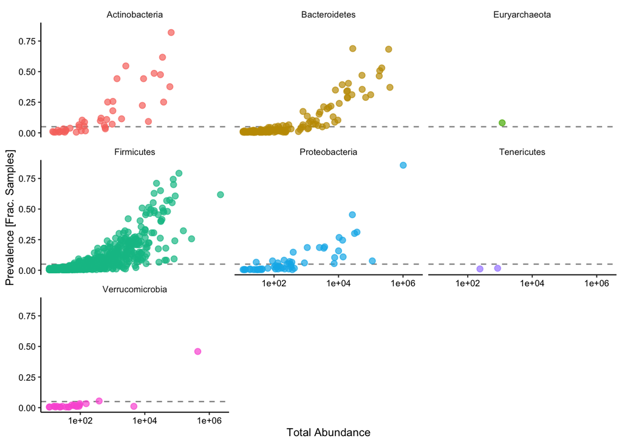

```r
# Subset to the remaining phyla
prevdf1 = subset(prevdf, Phylum %in% get_taxa_unique(ps0, "Phylum"))

ggplot(prevdf1, aes(TotalAbundance, Prevalence / nsamples(ps0),color=Phylum)) +
  # Include a guess for parameter
  geom_hline(yintercept = 0.05, alpha = 0.5, linetype = 2) + geom_point(size = 2, alpha = 0.7) +
  scale_x_log10() + xlab("Total Abundance") + ylab("Prevalence [Frac. Samples]") +
  facet_wrap(~Phylum) + theme(legend.position="none")
```

```r
# Define prevalence threshold as 5% of total samples
prevalenceThreshold = 0.05 * nsamples(ps0)
prevalenceThreshold
```

```
## [1] 9.15
```

```r
#Report number in each taxanomic rank
for (i in rank_names(ps)) {
  print(paste("Number of ",i,":",sep=""))
  print(length(get_taxa_unique(ps0, taxonomic.rank = i)))
}
```

```
## [1] "Number of Kingdom:"
## [1] 2
## [1] "Number of Phylum:"
## [1] 7
## [1] "Number of Class:"
## [1] 14
## [1] "Number of Order:"
## [1] 20
## [1] "Number of Family:"
## [1] 42
## [1] "Number of Genus:"
## [1] 150
## [1] "Number of Species:"
## [1] 160
## [1] "Number of SV:"
## [1] 937
```

## 3.7 Remove Samples with Low Reads

```r
#remove samples with fewer than 1000 reads
arbitraryCutOff=1000
ps0 <- prune_samples(sample_sums(ps0)>=arbitraryCutOff, ps0)
```

## 3.8 Transform Data

Create transformed versions of the data to perform subsequent analyses.

```r
#Convenience functions for geometric mean and clr transform; all x are > 0 because of filtering that was done
gm_mean = function(x, na.rm=TRUE){
  # The geometric mean, with some error-protection bits.
  exp(sum(log(x[x > 0 & !is.na(x)]), na.rm=na.rm) / length(x))
  }

clr = function(x, base=2){
  x <- log((x / gm_mean(x)), base)
  x[!is.finite(x) | is.na(x)] <- 0.0
  return(x)
  }

#clr transform data for PCoA, multivariate analysis
ps_clr <- transform_sample_counts(ps0, clr )

#proportion data for visualization
ps_prop <- transform_sample_counts(ps0, function (x) x/sum(x))

#rarefied data for ANOSIM and PERMANOVA
set.seed(25123)
ps_rarefied <- rarefy_even_depth(ps0, sample.size=1000)
```

# 4 Analysis of RA Ex Vivo Samples

## 4.1 Alpha Diversity

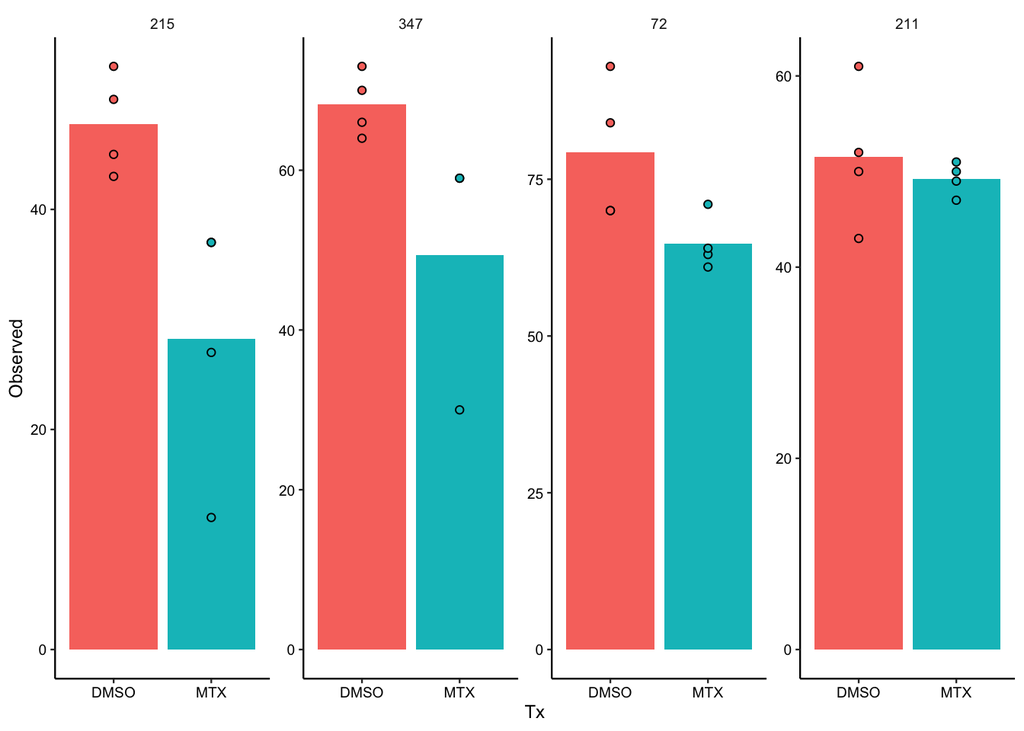

```r
ps_RA=subset_samples(ps0, exp=="RAexVivo")
a=sample_data(ps_RA)
a$well=str_c(a$Row,a$Patient)
sample_data(ps_RA) <- a
a <- as.data.frame(sample_data(ps_RA))

er_ra=estimate_richness(subset_samples(ps_RA, TimePoint=="24" & SampleInfo=="ex vivo"))
er_ra2=rownames_to_column(er_ra, "Sample.Label") %>% left_join(as_tibble(a), by="Sample.Label")
er_ra2$Patient=factor(er_ra2$Patient, levels=c("215","347", "72","211"))
er_ra2$Tx=as.factor(er_ra2$Tx)
ggplot(er_ra2, aes (x=Tx, y=Observed, group=Patient, fill=Tx)) + geom_bar(stat="summary", fun.y="mean") +
  geom_point(shape=21) + facet_wrap(~Patient, nrow=1, scales="free") + theme(legend.position = "none")
```

```r
library(nlme)
er_nlme=lme(Observed~Tx, random=~1|Patient, data=er_ra2, na.action=na.omit)
summary(er_nlme)
```

```
## Linear mixed-effects model fit by REML
##  Data: er_ra2
##        AIC     BIC    logLik
##   231.8458 237.315 -111.9229
##
## Random effects:
##  Formula: ~1 | Patient
##         (Intercept) Residual
## StdDev:    13.99483 8.946702
##
## Fixed effects: Observed ~ Tx
##                 Value Std.Error DF   t-value p-value
## (Intercept)  61.68750  7.346193 26  8.397206   0e+00
## TxMTX       -13.61719  3.220872 26 -4.227798   3e-04
##  Correlation:
##       (Intr)
## TxMTX -0.211
##
## Standardized Within-Group Residuals:
##        Min         Q1        Med         Q3        Max
## -2.4729652 -0.4678279  0.3593162  0.6839522  1.6792264
##
## Number of Observations: 31
## Number of Groups: 4
```

There is a reduction in alpha diversity (p=3x10-4, linear mixed effects model).

## 4.2 Beta Diversity

Examine PCA plots using clr transformed data.

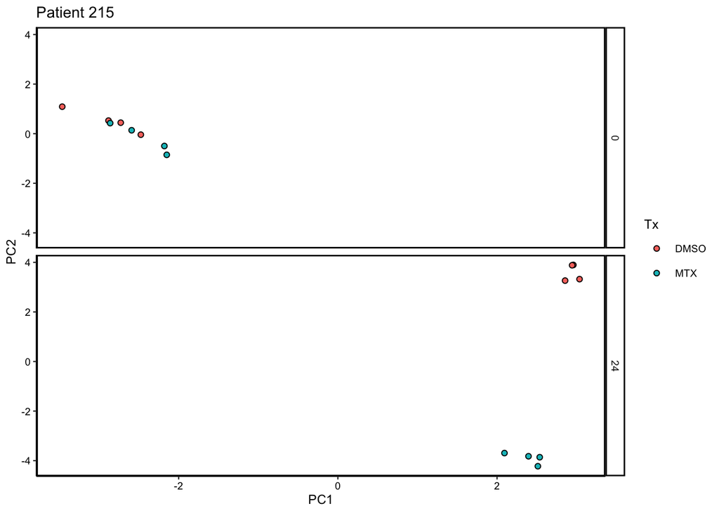

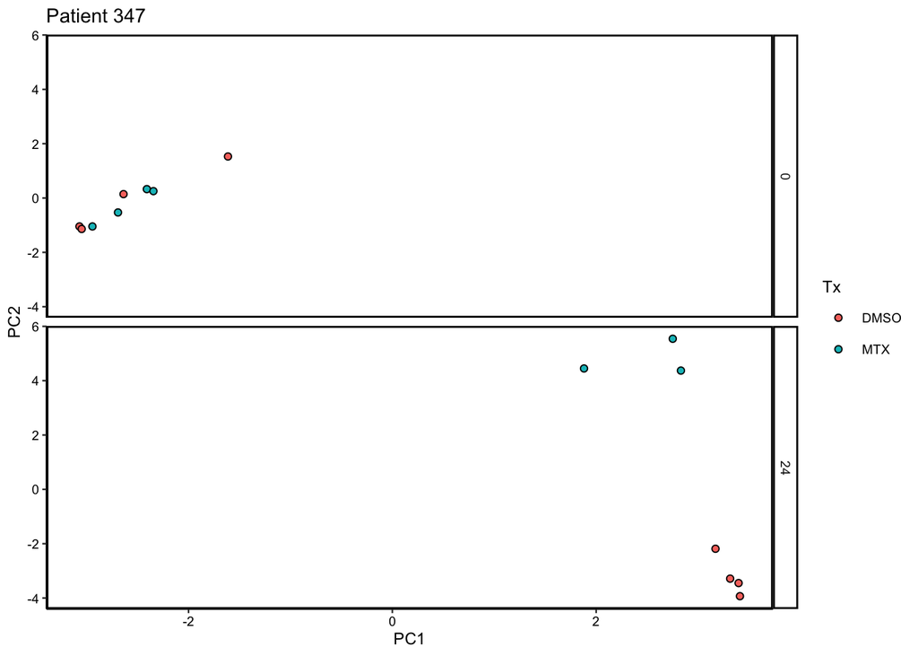

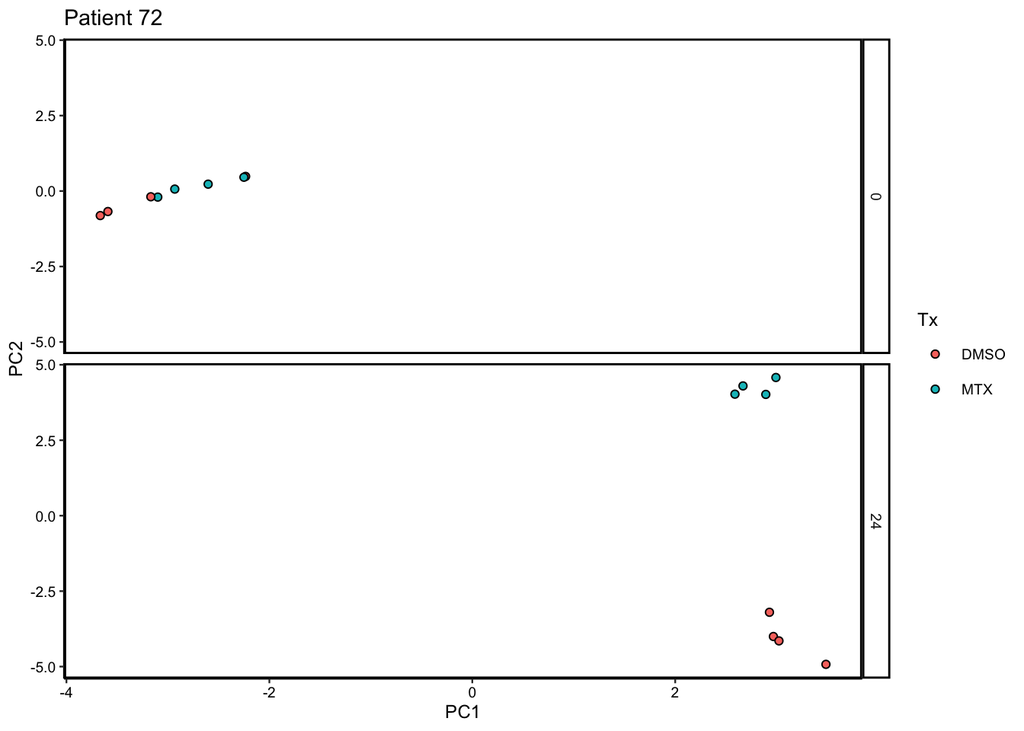

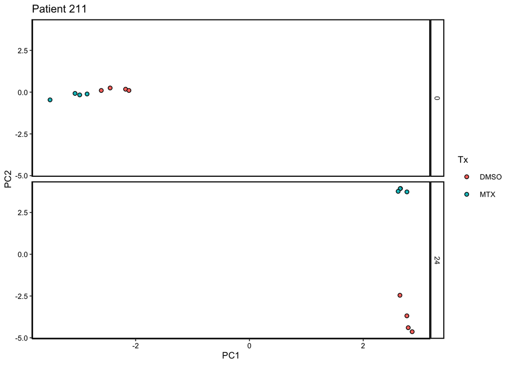

```r
ps_t <- ps_clr
ps_t_RA <- subset_samples(ps_t, exp=="RAexVivo" & SampleInfo=="ex vivo")
plotList=list()
patients=c(215,347, 72,211)
for (i in 1:4) {

   ps_t_pt <- subset_samples(ps_t_RA, Patient==patients[i] & TimePoint %in% c(0,24))
   PS.ord <- ordinate(ps_t_pt, "RDA", "euclidean")

  ggP_df<- plot_ordination(ps_t_pt, PS.ord, type="samples", color="Tx", justDF = T)
  ggP <- ggplot(data=ggP_df,aes(x=PC1,y=PC2,  fill=Tx, label=TimePoint)) + geom_point(shape=21) +
    facet_grid(TimePoint~.) +
    theme (panel.border = element_rect(color = "black", fill = NA, size = 1),
           strip.background = element_rect(color = "black", size = 1)) +
    ggtitle(paste("Patient",patients[i]))
  print(ggP)

  plotList[[i]] <- ggP
}
```

## 4.3 Hypothesis Testing

### 4.3.1 ANOSIM

```r
set.seed(25123)
ps_rarefied <- rarefy_even_depth(ps_RA, sample.size=5000)
library("vegan")
packageVersion("vegan")
```

```
## [1] '2.5.6'
```

```r
set.seed(10)
ps_t <- ps_rarefied

#Difference at 0 hours
for (i in c(0)) {
  for (j in c(215, 347,72, 211)) {
    ps_ano <- subset_samples(ps_t, TimePoint %in% c(i) & Patient==j & SampleInfo=="ex vivo")
    mtx_group = get_variable(ps_ano, "Tx")
    mtx_ano = anosim(phyloseq::distance(ps_ano, "bray"), mtx_group)
    print(mtx_ano)
  }
}
```

```
##
## Call:
## anosim(x = phyloseq::distance(ps_ano, "bray"), grouping = mtx_group)
## Dissimilarity: bray
##
## ANOSIM statistic R: 0.03571
##       Significance: 0.4
##
## Permutation: free
## Number of permutations: 719
##
##
## Call:
## anosim(x = phyloseq::distance(ps_ano, "bray"), grouping = mtx_group)
## Dissimilarity: bray
##
## ANOSIM statistic R:    -0
##       Significance: 0.66667
##
## Permutation: free
## Number of permutations: 5
##
##
## Call:
## anosim(x = phyloseq::distance(ps_ano, "bray"), grouping = mtx_group)
## Dissimilarity: bray
##
## ANOSIM statistic R: -0.1146
##       Significance: 0.754
##
## Permutation: free
## Number of permutations: 999
##
##
## Call:
## anosim(x = phyloseq::distance(ps_ano, "bray"), grouping = mtx_group)
## Dissimilarity: bray
##
## ANOSIM statistic R: 0.3542
##       Significance: 0.024
##
## Permutation: free
## Number of permutations: 999
```

```r
#Difference at 24 hours
for (i in c(24)) {
  for (j in c(215, 347,72, 211)) {
    ps_ano <- subset_samples(ps_t, TimePoint %in% c(i) & Patient==j & SampleInfo=="ex vivo")
    mtx_group = get_variable(ps_ano, "Tx")
    mtx_ano = anosim(phyloseq::distance(ps_ano, "bray"), mtx_group)
    print(mtx_ano)
  }
}
```

```
##
## Call:
## anosim(x = phyloseq::distance(ps_ano, "bray"), grouping = mtx_group)
## Dissimilarity: bray
##
## ANOSIM statistic R: 0.625
##       Significance: 0.031
##
## Permutation: free
## Number of permutations: 999
##
##
## Call:
## anosim(x = phyloseq::distance(ps_ano, "bray"), grouping = mtx_group)
## Dissimilarity: bray
##
## ANOSIM statistic R: 0.6111
##       Significance: 0.034
##
## Permutation: free
## Number of permutations: 5039
##
##
## Call:
## anosim(x = phyloseq::distance(ps_ano, "bray"), grouping = mtx_group)
## Dissimilarity: bray
##
## ANOSIM statistic R:     1
##       Significance: 0.026
##
## Permutation: free
## Number of permutations: 999
##
##
## Call:
## anosim(x = phyloseq::distance(ps_ano, "bray"), grouping = mtx_group)
## Dissimilarity: bray
##
## ANOSIM statistic R: 0.5625
##       Significance: 0.036
##
## Permutation: free
## Number of permutations: 999
```

### 4.3.2 PERMANOVA

```r
#PERMANOVA testing
# Adonis test to determine whether methotrexate tx influences community composition at 24h.
set.seed(1)
ps_t <- ps_rarefied
ps_perma <-  subset_samples(ps_t, TimePoint %in% c(24) & SampleInfo=="ex vivo")
ps_perma_bray <- phyloseq::distance(ps_perma, method = "bray")
sampledf <- data.frame(sample_data(ps_perma))
adonis(ps_perma_bray ~ Tx + Patient, data = sampledf)
```

```
##
## Call:
## adonis(formula = ps_perma_bray ~ Tx + Patient, data = sampledf)
##
## Permutation: free
## Number of permutations: 999
##
## Terms added sequentially (first to last)
##
##           Df SumsOfSqs MeanSqs F.Model      R2 Pr(>F)
## Tx         1    0.1900 0.19001  15.114 0.03134  0.001 ***
## Patient    3    5.5461 1.84870 147.048 0.91475  0.001 ***
## Residuals 26    0.3269 0.01257         0.05391
## Total     30    6.0630                 1.00000
## ---
## Signif. codes:  0 '***' 0.001 '**' 0.01 '*' 0.05 '.' 0.1 ' ' 1
```

```r
print("beta dispersion testing")
```

```
## [1] "beta dispersion testing"
```

```r
beta <- betadisper(ps_perma_bray, sampledf$Tx)
permutest(beta) #tests whether differences are due to group dispersions (if they are, then p will be significant)
```

```
##
## Permutation test for homogeneity of multivariate dispersions
## Permutation: free
## Number of permutations: 999
##
## Response: Distances
##           Df  Sum Sq  Mean Sq     F N.Perm Pr(>F)
## Groups     1 0.00004 0.000045 7e-04    999  0.975
## Residuals 29 1.95181 0.067304
```

Suggests that at 24 hours there is a difference between MTX and DMSO.

## 4.4 Phylum Level Trends

Perform stats on phylum level changes by patient for other phyla

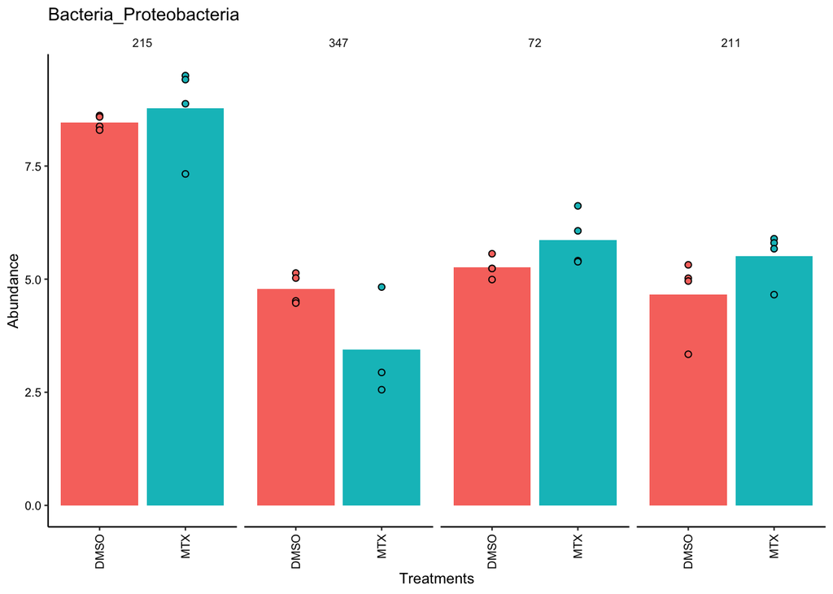

```
## [1] "Proteobacteria"
##     TxMTX
## 0.5743652
```

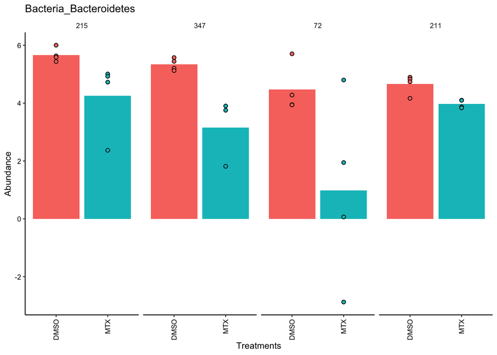

```
## [1] "Bacteroidetes"
##        TxMTX
## 0.0006544405
```

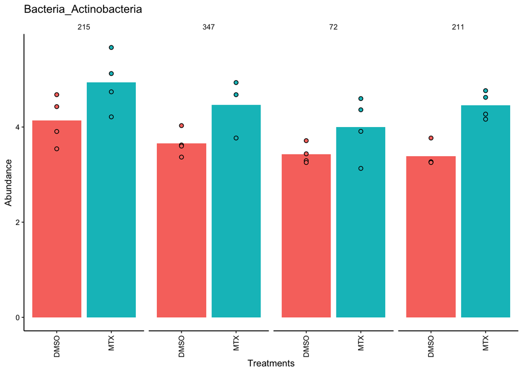

```
## [1] "Actinobacteria"
##       TxMTX
## 2.17452e-05
```

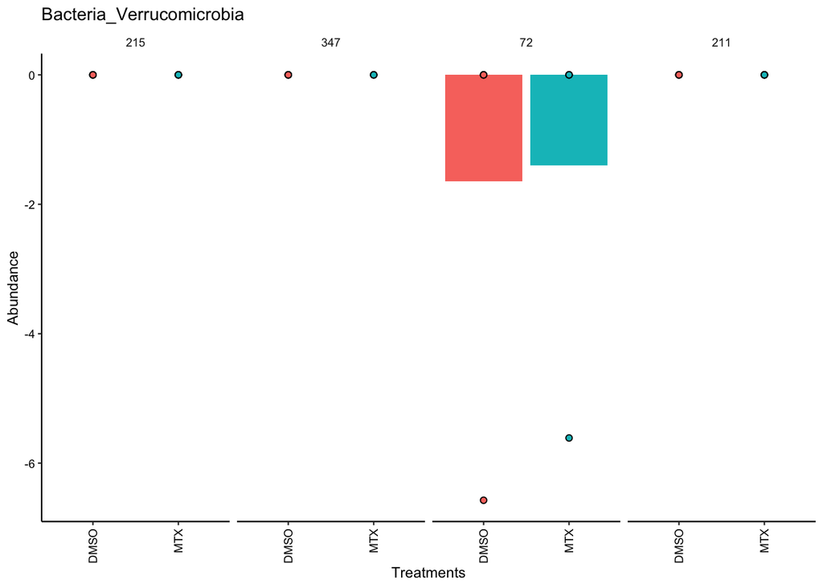

```
## [1] "Verrucomicrobia"
##     TxMTX
## 0.9254334
```

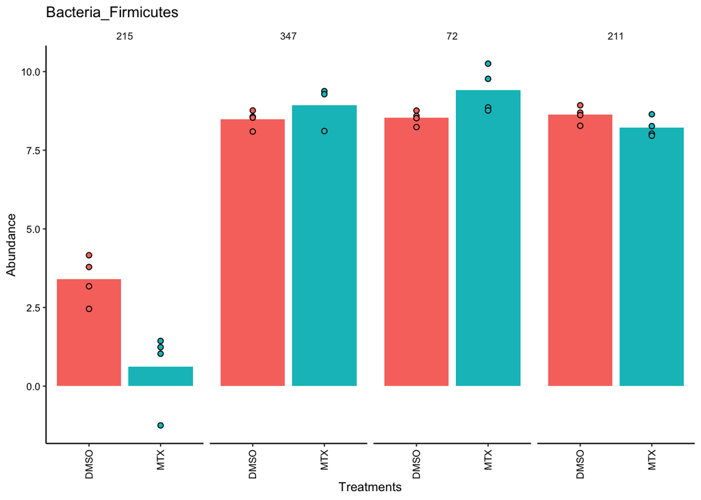

```
## [1] "Firmicutes"
##     TxMTX
## 0.1722289
```

```r
ps_phylum0 = tax_glom(ps_RA, "Phylum", NArm = TRUE)
ps_phylum = transform_sample_counts(ps_phylum0, clr)

ps_p <- subset_samples(ps_phylum, TimePoint %in% c(24) & SampleInfo=="ex vivo") #PICK A TIMEPOINT to examine

for (i in c(2,3,5,6,7)) {
  #1 and 4 are excluded because they are  Euryarchaeota and Tenericutes,
  #which throw an error (overfit models) lb/c of low abundance/prevalence

  #visualize
  ph <- rownames(tax_table(ps_p))
  o <- ph[i]
  o_names <- as(tax_table(ps_p)[o,], "matrix")
  o_title <- paste(o_names[1],o_names[2], sep="_")
  y_ps = otu_table(ps_p)[o,]
  y_df = psmelt(y_ps)
  y_df <- cbind(y_df, sample_data(ps_p)[y_df$Sample, c("Tx", "Patient","well")])
  colnames(y_df) = c("OTU","Sample","Abundance","Tx", "Patient","well")
  y_df$Patient=factor(y_df$Patient, levels=c("215","347","72", "211"))
  g <- ggplot(y_df) +  aes(x=Tx, y=Abundance, fill=Tx) +
    geom_bar(stat = "summary", fun.y = "mean") +
    geom_point(shape=21, color="black") +
    xlab("Treatments") + facet_grid(~Patient) +
    theme(axis.text.x = element_text(angle = 90, hjust =1, vjust=0.5), legend.position = "none") +
    ggtitle(o_title)
  print(g)

  #mixed effects linear model to test effect of tx on abundace
  b_nlme <- lme(Abundance~Tx, random= ~1|Patient, data= y_df)
  print(o_names[2])
  print(summary(b_nlme)$tTable[,5][2])
}
```

# 5 DESeq Analysis

## 5.1 ASV Level

```r
library(DESeq2)
#Use Deseq to identify differentially abundant RSVs
#https://www.bioconductor.org/packages/devel/bioc/vignettes/phyloseq/inst/doc/phyloseq-mixture-models.html

alpha = 0.01 #SET significance threshold use 0.01 for RSVs throughout the manuscript
set.seed(10)

#time 24h
ps_deseq <- subset_samples(ps_RA,SampleInfo=="ex vivo")
ps_deseq=subset_samples(ps_deseq,
                        Tx %in% c("DMSO","MTX") & TimePoint %in% c(24))
deseq_mtx=phyloseq_to_deseq2(ps_deseq, ~ Patient + Tx)
geoMeans = apply(counts(deseq_mtx), 1, gm_mean)
deseq_mtx = estimateSizeFactors(deseq_mtx, geoMeans = geoMeans)
deseq_mtx = DESeq(deseq_mtx, test="Wald", fitType="parametric")
res = results(deseq_mtx, cooksCutoff = FALSE)
res2 = cbind(as(res, "data.frame"), as(tax_table(ps_deseq)[rownames(res), ], "matrix"))
sigtab = res[which(res$padj < alpha), ]  #SET significance threshold above
sigtab = cbind(as(sigtab, "data.frame"), as(tax_table(ps_deseq)[rownames(sigtab), ], "matrix"))
dim(sigtab)
```

```
## [1] 20 14
```

```r
print(paste("There are", dim(sigtab)[1],"differentially abundant ASVs with MTX treatment at 24h."))
```

```
## [1] "There are 20 differentially abundant ASVs with MTX treatment at 24h."
```

```r
sigtab_24 <- sigtab
res2_24 <- res2
```

### 5.1.1 Phylogenetic Tree

Tree of the ~20 RSVs that were differentially abundant at time 24

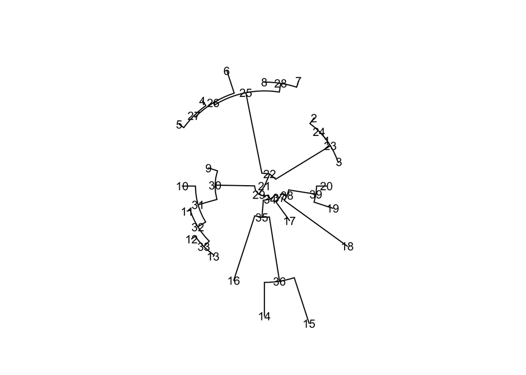

```r
library(ggtree)
library(tidytree)
library(plotly)

ra_ps=subset_samples(ps_RA, SampleInfo=="ex vivo")
ra_ps=filter_taxa(ra_ps, function(x) sum(x) > 0, TRUE)
ra_ps_sig=prune_taxa(rownames(sigtab_24), ra_ps)
ra_tree=phy_tree(ra_ps_sig)
rtt=as_tibble(ra_tree)
rtt2=left_join(rtt,rownames_to_column(sigtab_24,"label"),by="label")
ra_tree2=as.treedata(rtt2)

#visualize with a number of parameters
p <- ggtree(ra_tree2,layout="circular") +
  geom_point(aes(size=abs(log2FoldChange),color=as.factor(sign(log2FoldChange)), shape=Phylum))

#rotate branch to make proteobacteria together
ggtree(ra_tree2,layout="circular") + geom_text(aes(label=node))
```

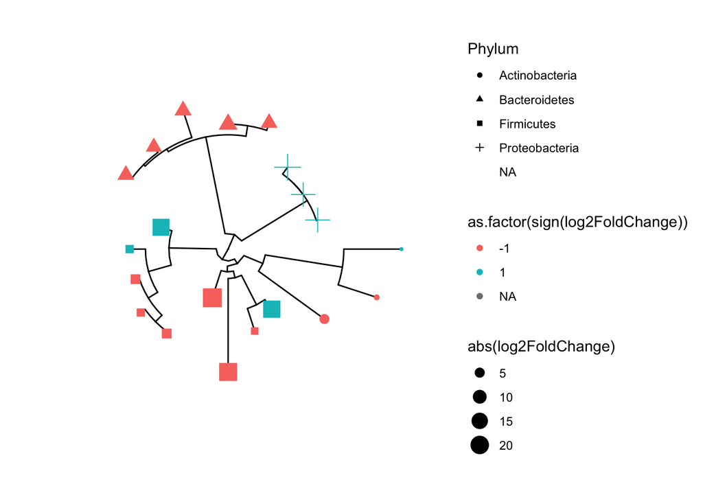

```r
flip(p, 35, 37)
```

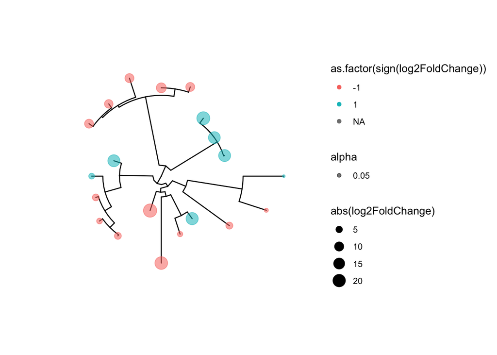

```r
#visualize again
p <- ggtree(ra_tree2,layout="circular") +
  geom_point(aes(size=abs(log2FoldChange),color=as.factor(sign(log2FoldChange)), alpha=0.05))
flip(p, 35, 37)
```

### 5.1.2 Genus Level DESeq

```r
library(DESeq2)
#Use Deseq to identify differentially abundant RSVs
#https://www.bioconductor.org/packages/devel/bioc/vignettes/phyloseq/inst/doc/phyloseq-mixture-models.html

alpha = 0.01 #SET significance threshold use 0.01 for RSVs throughout the manuscript
set.seed(10)
ps_RAgenus=tax_glom(ps_RA, "Genus", NArm=T)

#time 24h
ps_deseq <- subset_samples(ps_RAgenus,SampleInfo=="ex vivo")
ps_deseq=subset_samples(ps_deseq,
                        Tx %in% c("DMSO","MTX") & TimePoint %in% c(24))
deseq_mtx=phyloseq_to_deseq2(ps_deseq, ~ Patient + Tx)
geoMeans = apply(counts(deseq_mtx), 1, gm_mean)
deseq_mtx = estimateSizeFactors(deseq_mtx, geoMeans = geoMeans)
deseq_mtx = DESeq(deseq_mtx, test="Wald", fitType="parametric")
res = results(deseq_mtx, cooksCutoff = FALSE)
res2 = cbind(as(res, "data.frame"), as(tax_table(ps_deseq)[rownames(res), ], "matrix"))
sigtab = res[which(res$padj < alpha), ]  #SET significance threshold above
sigtab = cbind(as(sigtab, "data.frame"), as(tax_table(ps_deseq)[rownames(sigtab), ], "matrix"))
dim(sigtab)
```

```
## [1] 17 14
```

```r
print(paste("There are", dim(sigtab)[1],"differentially abundant genera with MTX treatment at 24h."))
```

```
## [1] "There are 17 differentially abundant genera with MTX treatment at 24h."
```

```r
sigtab_24_genus <- sigtab # 16 significant
res2_24 <- res2
```

## 5.2 Phylum Level DESeq

```r
library(DESeq2)
#Use Deseq to identify differentially abundant RSVs
#https://www.bioconductor.org/packages/devel/bioc/vignettes/phyloseq/inst/doc/phyloseq-mixture-models.html

alpha = 0.01 #SET significance threshold use 0.01 for RSVs throughout the manuscript
set.seed(10)
ps_RAphylum=tax_glom(ps_RA, "Phylum", NArm=T)

#time 24h
ps_deseq <- subset_samples(ps_RAphylum,SampleInfo=="ex vivo")
ps_deseq=subset_samples(ps_deseq,
                        Tx %in% c("DMSO","MTX") & TimePoint %in% c(24))
deseq_mtx=phyloseq_to_deseq2(ps_deseq, ~ Patient + Tx)
geoMeans = apply(counts(deseq_mtx), 1, gm_mean)
deseq_mtx = estimateSizeFactors(deseq_mtx, geoMeans = geoMeans)
deseq_mtx = DESeq(deseq_mtx, test="Wald", fitType="parametric")
res = results(deseq_mtx, cooksCutoff = FALSE)
res2 = cbind(as(res, "data.frame"), as(tax_table(ps_deseq)[rownames(res), ], "matrix"))
sigtab = res[which(res$padj < alpha), ]  #SET significance threshold above
sigtab = cbind(as(sigtab, "data.frame"), as(tax_table(ps_deseq)[rownames(sigtab), ], "matrix"))
dim(sigtab)
```

```
## [1]  2 14
```

```r
print(paste("There are", dim(sigtab)[1],"differentially abundant phyla with MTX treatment at 24h."))
```

```
## [1] "There are 2 differentially abundant phyla with MTX treatment at 24h."
```

```r
sigtab_24_phy <- sigtab
res2_24 <- res2
```

Bacteroidetes decrease and Actinobacteria increase at 24 hours.